# Risk Factor Analysis

## Outcome Variable

**Outcome Variable:** whz

## Predictor Variables

**Intervention Variable:** impfloor

**Adjustment Set:**

- arm
- sex
- W_mage
- meducyrs
- feducyrs
- hhwealth_quart
- hfoodsec
- W_mhtcm
- W_mwtkg
- W_mbmi
- W_nrooms
- W_nchldlt5
- W_parity
- impsan
- safeh20
- delta_W_mage
- delta_meducyrs
- delta_feducyrs
- delta_hhwealth_quart
- delta_hfoodsec
- delta_W_mhtcm
- delta_W_mwtkg
- delta_W_mbmi
- delta_W_nrooms
- delta_W_nchldlt5
- delta_W_parity
- delta_impsan
- delta_safeh20

## Stratifying Variables

The analysis was stratified on these variable(s):

- agecat
- studyid
- country

## Data Summary

| agecat | studyid | country | impfloor | n_cell | n | outcome_variable |
| --- | --- | --- | --- | --- | --- | --- |
| Birth | ki0047075b-MAL-ED | BANGLADESH | 1 | 185 | 201 | whz |
| Birth | ki0047075b-MAL-ED | BANGLADESH | 0 | 16 | 201 | whz |
| Birth | ki0047075b-MAL-ED | BRAZIL | 1 | 55 | 57 | whz |
| Birth | ki0047075b-MAL-ED | BRAZIL | 0 | 2 | 57 | whz |
| Birth | ki0047075b-MAL-ED | INDIA | 1 | 33 | 39 | whz |
| Birth | ki0047075b-MAL-ED | INDIA | 0 | 6 | 39 | whz |
| Birth | ki0047075b-MAL-ED | NEPAL | 1 | 8 | 24 | whz |
| Birth | ki0047075b-MAL-ED | NEPAL | 0 | 16 | 24 | whz |
| Birth | ki0047075b-MAL-ED | PERU | 1 | 37 | 210 | whz |
| Birth | ki0047075b-MAL-ED | PERU | 0 | 173 | 210 | whz |
| Birth | ki0047075b-MAL-ED | SOUTH AFRICA | 1 | 86 | 95 | whz |
| Birth | ki0047075b-MAL-ED | SOUTH AFRICA | 0 | 9 | 95 | whz |
| Birth | ki0047075b-MAL-ED | TANZANIA, UNITED REPUBLIC OF | 1 | 5 | 111 | whz |
| Birth | ki0047075b-MAL-ED | TANZANIA, UNITED REPUBLIC OF | 0 | 106 | 111 | whz |
| Birth | ki1000108-CMC-V-BCS-2002 | INDIA | 1 | 68 | 68 | whz |
| Birth | ki1000108-CMC-V-BCS-2002 | INDIA | 0 | 0 | 68 | whz |
| Birth | ki1000108-IRC | INDIA | 1 | 253 | 253 | whz |
| Birth | ki1000108-IRC | INDIA | 0 | 0 | 253 | whz |
| Birth | ki1017093-NIH-Birth | BANGLADESH | 1 | 505 | 572 | whz |
| Birth | ki1017093-NIH-Birth | BANGLADESH | 0 | 67 | 572 | whz |
| Birth | ki1017093b-PROVIDE | BANGLADESH | 1 | 485 | 532 | whz |
| Birth | ki1017093b-PROVIDE | BANGLADESH | 0 | 47 | 532 | whz |
| Birth | ki1017093c-NIH-Crypto | BANGLADESH | 1 | 542 | 707 | whz |
| Birth | ki1017093c-NIH-Crypto | BANGLADESH | 0 | 165 | 707 | whz |
| Birth | ki1113344-GMS-Nepal | NEPAL | 1 | 97 | 503 | whz |
| Birth | ki1113344-GMS-Nepal | NEPAL | 0 | 406 | 503 | whz |
| Birth | ki1114097-CONTENT | PERU | 1 | 2 | 2 | whz |
| Birth | ki1114097-CONTENT | PERU | 0 | 0 | 2 | whz |
| Birth | kiGH5241-JiVitA-3 | BANGLADESH | 1 | 1215 | 17966 | whz |
| Birth | kiGH5241-JiVitA-3 | BANGLADESH | 0 | 16751 | 17966 | whz |

[output cut: 66 more lines]

The following strata were considered:

- agecat: 24 months, studyid: ki0047075b-MAL-ED, country: BANGLADESH
- agecat: 24 months, studyid: ki0047075b-MAL-ED, country: BRAZIL
- agecat: 24 months, studyid: ki0047075b-MAL-ED, country: INDIA
- agecat: 24 months, studyid: ki0047075b-MAL-ED, country: NEPAL
- agecat: 24 months, studyid: ki0047075b-MAL-ED, country: PERU
- agecat: 24 months, studyid: ki0047075b-MAL-ED, country: SOUTH AFRICA
- agecat: 24 months, studyid: ki0047075b-MAL-ED, country: TANZANIA, UNITED REPUBLIC OF
- agecat: 24 months, studyid: ki1000108-CMC-V-BCS-2002, country: INDIA
- agecat: 24 months, studyid: ki1000108-IRC, country: INDIA
- agecat: 24 months, studyid: ki1017093-NIH-Birth, country: BANGLADESH
- agecat: 24 months, studyid: ki1017093b-PROVIDE, country: BANGLADESH
- agecat: 24 months, studyid: ki1017093c-NIH-Crypto, country: BANGLADESH
- agecat: 24 months, studyid: ki1113344-GMS-Nepal, country: NEPAL
- agecat: 24 months, studyid: ki1114097-CONTENT, country: PERU
- agecat: 24 months, studyid: kiGH5241-JiVitA-3, country: BANGLADESH
- agecat: 24 months, studyid: kiGH5241-JiVitA-4, country: BANGLADESH
- agecat: 6 months, studyid: ki0047075b-MAL-ED, country: BANGLADESH
- agecat: 6 months, studyid: ki0047075b-MAL-ED, country: BRAZIL
- agecat: 6 months, studyid: ki0047075b-MAL-ED, country: INDIA
- agecat: 6 months, studyid: ki0047075b-MAL-ED, country: NEPAL
- agecat: 6 months, studyid: ki0047075b-MAL-ED, country: PERU
- agecat: 6 months, studyid: ki0047075b-MAL-ED, country: SOUTH AFRICA
- agecat: 6 months, studyid: ki0047075b-MAL-ED, country: TANZANIA, UNITED REPUBLIC OF
- agecat: 6 months, studyid: ki1000108-CMC-V-BCS-2002, country: INDIA
- agecat: 6 months, studyid: ki1000108-IRC, country: INDIA
- agecat: 6 months, studyid: ki1017093-NIH-Birth, country: BANGLADESH
- agecat: 6 months, studyid: ki1017093b-PROVIDE, country: BANGLADESH
- agecat: 6 months, studyid: ki1017093c-NIH-Crypto, country: BANGLADESH
- agecat: 6 months, studyid: ki1113344-GMS-Nepal, country: NEPAL
- agecat: 6 months, studyid: ki1114097-CONTENT, country: PERU
- agecat: 6 months, studyid: kiGH5241-JiVitA-3, country: BANGLADESH
- agecat: 6 months, studyid: kiGH5241-JiVitA-4, country: BANGLADESH
- agecat: Birth, studyid: ki0047075b-MAL-ED, country: BANGLADESH
- agecat: Birth, studyid: ki0047075b-MAL-ED, country: BRAZIL
- agecat: Birth, studyid: ki0047075b-MAL-ED, country: INDIA
- agecat: Birth, studyid: ki0047075b-MAL-ED, country: NEPAL
- agecat: Birth, studyid: ki0047075b-MAL-ED, country: PERU
- agecat: Birth, studyid: ki0047075b-MAL-ED, country: SOUTH AFRICA
- agecat: Birth, studyid: ki0047075b-MAL-ED, country: TANZANIA, UNITED REPUBLIC OF
- agecat: Birth, studyid: ki1000108-CMC-V-BCS-2002, country: INDIA
- agecat: Birth, studyid: ki1000108-IRC, country: INDIA
- agecat: Birth, studyid: ki1017093-NIH-Birth, country: BANGLADESH
- agecat: Birth, studyid: ki1017093b-PROVIDE, country: BANGLADESH
- agecat: Birth, studyid: ki1017093c-NIH-Crypto, country: BANGLADESH
- agecat: Birth, studyid: ki1113344-GMS-Nepal, country: NEPAL
- agecat: Birth, studyid: ki1114097-CONTENT, country: PERU
- agecat: Birth, studyid: kiGH5241-JiVitA-3, country: BANGLADESH
- agecat: Birth, studyid: kiGH5241-JiVitA-4, country: BANGLADESH

### Dropped Strata

- agecat: Birth, studyid: ki0047075b-MAL-ED, country: BRAZIL
- agecat: Birth, studyid: ki1000108-CMC-V-BCS-2002, country: INDIA
- agecat: Birth, studyid: ki1000108-IRC, country: INDIA
- agecat: Birth, studyid: ki1114097-CONTENT, country: PERU
- agecat: 6 months, studyid: ki0047075b-MAL-ED, country: BRAZIL
- agecat: 6 months, studyid: ki1000108-CMC-V-BCS-2002, country: INDIA
- agecat: 6 months, studyid: ki1000108-IRC, country: INDIA
- agecat: 24 months, studyid: ki0047075b-MAL-ED, country: BRAZIL
- agecat: 24 months, studyid: ki1000108-CMC-V-BCS-2002, country: INDIA
- agecat: 24 months, studyid: ki1000108-IRC, country: INDIA

## Methods Detail

We’re interested in the causal parameters $E[Y_a]$ for all values of $a \in \mathcal{A}$. These parameters represent the mean outcome if, possibly contrary to fact, we intervened to set all units to have $A=a$. Under the randomization and positivity assumptions, these are identified by the statistical parameters $\psi_a=E_W[E_{Y|A,W}(Y|A=a,W)]$. In addition, we’re interested in the mean of $Y$, $E[Y]$ under no intervention (the observed mean). We will estimate these parameters by using SuperLearner to fit the relevant likelihood factors – $E_{Y|A,W}(Y|A=a,W)$ and $p(A=a|W)$, and then updating our likelihood fit using a joint TMLE.

For unadjusted analyses ($W=\{\}$), initial likelihoods were estimated using Lrnr_glm to estimate the simple $E(Y|A)$ and Lrnr_mean to estimate $p(A)$. For adjusted analyses, a small library containing Lrnr_glmnet, Lrnr_xgboost, and Lrnr_mean was used.

Having estimated these parameters, we will then use the delta method to estimate relative risks and attributable risks relative to a prespecified baseline level of $A$.

# Results Detail

## Results Plots

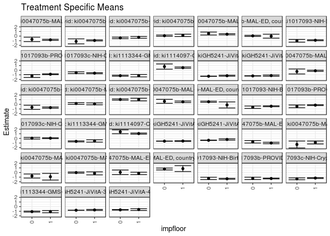

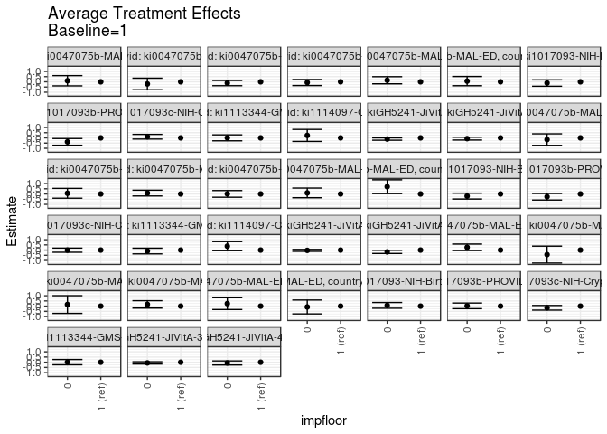

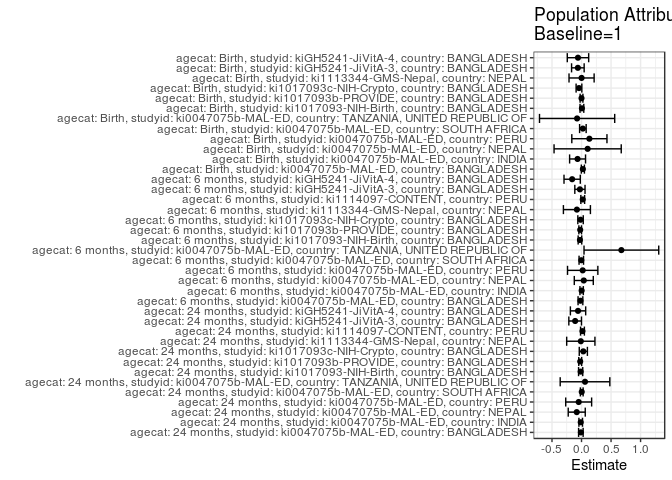

## Results Table

### Parameter: TSM

| agecat | studyid | country | intervention_level | baseline_level | estimate | ci_lower | ci_upper |
| --- | --- | --- | --- | --- | --- | --- | --- |
| Birth | ki0047075b-MAL-ED | BANGLADESH | 1 | NA | -0.9957205 | -1.1553631 | -0.8360779 |
| Birth | ki0047075b-MAL-ED | BANGLADESH | 0 | NA | -0.7310774 | -0.9997417 | -0.4624131 |
| Birth | ki0047075b-MAL-ED | INDIA | 1 | NA | -0.8772727 | -1.1935310 | -0.5610144 |
| Birth | ki0047075b-MAL-ED | INDIA | 0 | NA | -1.3116667 | -2.0623390 | -0.5609943 |
| Birth | ki0047075b-MAL-ED | NEPAL | 1 | NA | -0.9125000 | -1.6413488 | -0.1836512 |
| Birth | ki0047075b-MAL-ED | NEPAL | 0 | NA | -0.7568750 | -1.1980753 | -0.3156747 |
| Birth | ki0047075b-MAL-ED | PERU | 1 | NA | -0.1799450 | -0.5069884 | 0.1470984 |
| Birth | ki0047075b-MAL-ED | PERU | 0 | NA | -0.0111147 | -0.1473181 | 0.1250887 |
| Birth | ki0047075b-MAL-ED | SOUTH AFRICA | 1 | NA | -0.1959302 | -0.4617510 | 0.0698905 |
| Birth | ki0047075b-MAL-ED | SOUTH AFRICA | 0 | NA | 0.0466667 | -0.4532880 | 0.5466213 |
| Birth | ki0047075b-MAL-ED | TANZANIA, UNITED REPUBLIC OF | 1 | NA | 0.8440000 | 0.2094403 | 1.4785597 |
| Birth | ki0047075b-MAL-ED | TANZANIA, UNITED REPUBLIC OF | 0 | NA | 0.7655660 | 0.5608207 | 0.9703114 |
| Birth | ki1017093-NIH-Birth | BANGLADESH | 1 | NA | -1.3512903 | -1.4530637 | -1.2495170 |
| Birth | ki1017093-NIH-Birth | BANGLADESH | 0 | NA | -1.2774633 | -1.5334579 | -1.0214688 |
| Birth | ki1017093b-PROVIDE | BANGLADESH | 1 | NA | -1.2982579 | -1.3786512 | -1.2178645 |
| Birth | ki1017093b-PROVIDE | BANGLADESH | 0 | NA | -1.2702567 | -1.5265575 | -1.0139560 |
| Birth | ki1017093c-NIH-Crypto | BANGLADESH | 1 | NA | -1.2009661 | -1.2952192 | -1.1067130 |
| Birth | ki1017093c-NIH-Crypto | BANGLADESH | 0 | NA | -1.3589861 | -1.5609865 | -1.1569858 |
| Birth | ki1113344-GMS-Nepal | NEPAL | 1 | NA | -1.0869499 | -1.3186053 | -0.8552946 |
| Birth | ki1113344-GMS-Nepal | NEPAL | 0 | NA | -1.0794881 | -1.1884554 | -0.9705207 |
| Birth | kiGH5241-JiVitA-3 | BANGLADESH | 1 | NA | -0.7153880 | -0.8237410 | -0.6070350 |
| Birth | kiGH5241-JiVitA-3 | BANGLADESH | 0 | NA | -0.7816270 | -0.8015195 | -0.7617345 |
| Birth | kiGH5241-JiVitA-4 | BANGLADESH | 1 | NA | -0.6283015 | -0.8173814 | -0.4392217 |
| Birth | kiGH5241-JiVitA-4 | BANGLADESH | 0 | NA | -0.6984578 | -0.7555396 | -0.6413759 |
| 6 months | ki0047075b-MAL-ED | BANGLADESH | 1 | NA | -0.1151383 | -0.2491283 | 0.0188516 |
| 6 months | ki0047075b-MAL-ED | BANGLADESH | 0 | NA | -0.2791905 | -0.8165276 | 0.2581467 |
| 6 months | ki0047075b-MAL-ED | INDIA | 1 | NA | -0.7122716 | -0.8460481 | -0.5784951 |
| 6 months | ki0047075b-MAL-ED | INDIA | 0 | NA | -0.6481463 | -1.1005936 | -0.1956991 |
| 6 months | ki0047075b-MAL-ED | NEPAL | 1 | NA | 0.0897372 | -0.1163305 | 0.2958049 |
| 6 months | ki0047075b-MAL-ED | NEPAL | 0 | NA | 0.1727563 | -0.0135758 | 0.3590884 |
| 6 months | ki0047075b-MAL-ED | PERU | 1 | NA | 1.0314230 | 0.7406279 | 1.3222182 |
| 6 months | ki0047075b-MAL-ED | PERU | 0 | NA | 1.0392698 | 0.9016572 | 1.1768824 |
| 6 months | ki0047075b-MAL-ED | SOUTH AFRICA | 1 | NA | 0.5441876 | 0.3809275 | 0.7074478 |
| 6 months | ki0047075b-MAL-ED | SOUTH AFRICA | 0 | NA | 0.6457869 | 0.2116179 | 1.0799559 |
| 6 months | ki0047075b-MAL-ED | TANZANIA, UNITED REPUBLIC OF | 1 | NA | -0.1393624 | -0.7914451 | 0.5127202 |
| 6 months | ki0047075b-MAL-ED | TANZANIA, UNITED REPUBLIC OF | 0 | NA | 0.5585831 | 0.4234201 | 0.6937461 |
| 6 months | ki1017093-NIH-Birth | BANGLADESH | 1 | NA | -0.4180579 | -0.5150078 | -0.3211081 |
| 6 months | ki1017093-NIH-Birth | BANGLADESH | 0 | NA | -0.6236898 | -0.8866453 | -0.3607344 |
| 6 months | ki1017093b-PROVIDE | BANGLADESH | 1 | NA | -0.1766971 | -0.2635343 | -0.0898599 |
| 6 months | ki1017093b-PROVIDE | BANGLADESH | 0 | NA | -0.4455824 | -0.7459449 | -0.1452198 |
| 6 months | ki1017093c-NIH-Crypto | BANGLADESH | 1 | NA | 0.0463540 | -0.0442943 | 0.1370023 |
| 6 months | ki1017093c-NIH-Crypto | BANGLADESH | 0 | NA | 0.0384353 | -0.1403924 | 0.2172630 |
| 6 months | ki1113344-GMS-Nepal | NEPAL | 1 | NA | -0.5493622 | -0.8013130 | -0.2974114 |
| 6 months | ki1113344-GMS-Nepal | NEPAL | 0 | NA | -0.6405379 | -0.7483375 | -0.5327383 |
| 6 months | ki1114097-CONTENT | PERU | 1 | NA | 1.0479615 | 0.9270559 | 1.1688671 |
| 6 months | ki1114097-CONTENT | PERU | 0 | NA | 1.4240225 | 1.0076962 | 1.8403487 |
| 6 months | kiGH5241-JiVitA-3 | BANGLADESH | 1 | NA | -0.5655727 | -0.6532612 | -0.4778843 |
| 6 months | kiGH5241-JiVitA-3 | BANGLADESH | 0 | NA | -0.5945448 | -0.6156029 | -0.5734867 |
| 6 months | kiGH5241-JiVitA-4 | BANGLADESH | 1 | NA | -0.2314377 | -0.3736146 | -0.0892609 |
| 6 months | kiGH5241-JiVitA-4 | BANGLADESH | 0 | NA | -0.4062147 | -0.4509850 | -0.3614444 |
| 24 months | ki0047075b-MAL-ED | BANGLADESH | 1 | NA | -0.8081243 | -0.9345330 | -0.6817156 |
| 24 months | ki0047075b-MAL-ED | BANGLADESH | 0 | NA | -0.7043271 | -1.1817506 | -0.2269036 |
| 24 months | ki0047075b-MAL-ED | INDIA | 1 | NA | -0.9381563 | -1.0580783 | -0.8182343 |
| 24 months | ki0047075b-MAL-ED | INDIA | 0 | NA | -1.1433622 | -1.6855821 | -0.6011424 |
| 24 months | ki0047075b-MAL-ED | NEPAL | 1 | NA | -0.2661566 | -0.4541071 | -0.0782061 |
| 24 months | ki0047075b-MAL-ED | NEPAL | 0 | NA | -0.3885627 | -0.5543840 | -0.2227413 |
| 24 months | ki0047075b-MAL-ED | PERU | 1 | NA | 0.1593688 | -0.0966311 | 0.4153687 |
| 24 months | ki0047075b-MAL-ED | PERU | 0 | NA | 0.0901790 | -0.0473566 | 0.2277145 |
| 24 months | ki0047075b-MAL-ED | SOUTH AFRICA | 1 | NA | 0.4052736 | 0.2761539 | 0.5343933 |
| 24 months | ki0047075b-MAL-ED | SOUTH AFRICA | 0 | NA | 0.5538406 | 0.2349913 | 0.8726899 |
| 24 months | ki0047075b-MAL-ED | TANZANIA, UNITED REPUBLIC OF | 1 | NA | -0.0113839 | -0.4349790 | 0.4122111 |
| 24 months | ki0047075b-MAL-ED | TANZANIA, UNITED REPUBLIC OF | 0 | NA | 0.0571170 | -0.0727989 | 0.1870330 |
| 24 months | ki1017093-NIH-Birth | BANGLADESH | 1 | NA | -0.8959273 | -1.0010344 | -0.7908201 |
| 24 months | ki1017093-NIH-Birth | BANGLADESH | 0 | NA | -1.0132568 | -1.2995146 | -0.7269989 |
| 24 months | ki1017093b-PROVIDE | BANGLADESH | 1 | NA | -0.8707498 | -0.9565253 | -0.7849743 |
| 24 months | ki1017093b-PROVIDE | BANGLADESH | 0 | NA | -1.2546190 | -1.5658819 | -0.9433562 |
| 24 months | ki1017093c-NIH-Crypto | BANGLADESH | 1 | NA | -0.6409875 | -0.7580640 | -0.5239110 |
| 24 months | ki1017093c-NIH-Crypto | BANGLADESH | 0 | NA | -0.5298031 | -0.7226332 | -0.3369731 |
| 24 months | ki1113344-GMS-Nepal | NEPAL | 1 | NA | -1.1870601 | -1.4479661 | -0.9261541 |
| 24 months | ki1113344-GMS-Nepal | NEPAL | 0 | NA | -1.1817868 | -1.3000914 | -1.0634823 |
| 24 months | ki1114097-CONTENT | PERU | 1 | NA | 0.5509633 | 0.4086393 | 0.6932873 |
| 24 months | ki1114097-CONTENT | PERU | 0 | NA | 0.7883148 | 0.2302684 | 1.3463612 |
| 24 months | kiGH5241-JiVitA-3 | BANGLADESH | 1 | NA | -1.1893546 | -1.3005480 | -1.0781611 |
| 24 months | kiGH5241-JiVitA-3 | BANGLADESH | 0 | NA | -1.3015096 | -1.3255296 | -1.2774896 |
| 24 months | kiGH5241-JiVitA-4 | BANGLADESH | 1 | NA | -1.1641212 | -1.2981359 | -1.0301064 |
| 24 months | kiGH5241-JiVitA-4 | BANGLADESH | 0 | NA | -1.2347007 | -1.2717300 | -1.1976715 |

### Parameter: E(Y)

| agecat | studyid | country | intervention_level | baseline_level | estimate | ci_lower | ci_upper |
| --- | --- | --- | --- | --- | --- | --- | --- |
| Birth | ki0047075b-MAL-ED | BANGLADESH | NA | NA | -0.9728358 | -1.1217009 | -0.8239707 |
| Birth | ki0047075b-MAL-ED | INDIA | NA | NA | -0.9441026 | -1.2397919 | -0.6484132 |
| Birth | ki0047075b-MAL-ED | NEPAL | NA | NA | -0.8087500 | -1.1914221 | -0.4260779 |
| Birth | ki0047075b-MAL-ED | PERU | NA | NA | -0.0468095 | -0.1738806 | 0.0802616 |
| Birth | ki0047075b-MAL-ED | SOUTH AFRICA | NA | NA | -0.1729474 | -0.4186222 | 0.0727275 |
| Birth | ki0047075b-MAL-ED | TANZANIA, UNITED REPUBLIC OF | NA | NA | 0.7690991 | 0.5714748 | 0.9667234 |
| Birth | ki1017093-NIH-Birth | BANGLADESH | NA | NA | -1.3448514 | -1.4396716 | -1.2500312 |
| Birth | ki1017093b-PROVIDE | BANGLADESH | NA | NA | -1.2984586 | -1.3752758 | -1.2216415 |
| Birth | ki1017093c-NIH-Crypto | BANGLADESH | NA | NA | -1.2441513 | -1.3281130 | -1.1601897 |
| Birth | ki1113344-GMS-Nepal | NEPAL | NA | NA | -1.0860636 | -1.1830454 | -0.9890818 |
| Birth | kiGH5241-JiVitA-3 | BANGLADESH | NA | NA | -0.7773511 | -0.7963777 | -0.7583245 |
| Birth | kiGH5241-JiVitA-4 | BANGLADESH | NA | NA | -0.6882498 | -0.7406539 | -0.6358456 |
| 6 months | ki0047075b-MAL-ED | BANGLADESH | NA | NA | -0.1333333 | -0.2623761 | -0.0042906 |
| 6 months | ki0047075b-MAL-ED | INDIA | NA | NA | -0.7102872 | -0.8371659 | -0.5834085 |
| 6 months | ki0047075b-MAL-ED | NEPAL | NA | NA | 0.1281441 | -0.0056126 | 0.2619008 |
| 6 months | ki0047075b-MAL-ED | PERU | NA | NA | 1.0512099 | 0.9285617 | 1.1738581 |
| 6 months | ki0047075b-MAL-ED | SOUTH AFRICA | NA | NA | 0.5404351 | 0.3867005 | 0.6941696 |
| 6 months | ki0047075b-MAL-ED | TANZANIA, UNITED REPUBLIC OF | NA | NA | 0.5355782 | 0.4032519 | 0.6679046 |
| 6 months | ki1017093-NIH-Birth | BANGLADESH | NA | NA | -0.4447399 | -0.5354039 | -0.3540758 |
| 6 months | ki1017093b-PROVIDE | BANGLADESH | NA | NA | -0.1990907 | -0.2817968 | -0.1163845 |
| 6 months | ki1017093c-NIH-Crypto | BANGLADESH | NA | NA | 0.0297622 | -0.0491685 | 0.1086930 |
| 6 months | ki1113344-GMS-Nepal | NEPAL | NA | NA | -0.6273772 | -0.7253868 | -0.5293676 |
| 6 months | ki1114097-CONTENT | PERU | NA | NA | 1.0684318 | 0.9515274 | 1.1853362 |
| 6 months | kiGH5241-JiVitA-3 | BANGLADESH | NA | NA | -0.5926720 | -0.6122891 | -0.5730549 |
| 6 months | kiGH5241-JiVitA-4 | BANGLADESH | NA | NA | -0.3901347 | -0.4273932 | -0.3528762 |
| 24 months | ki0047075b-MAL-ED | BANGLADESH | NA | NA | -0.8192925 | -0.9412667 | -0.6973182 |
| 24 months | ki0047075b-MAL-ED | INDIA | NA | NA | -0.9516520 | -1.0670654 | -0.8362385 |
| 24 months | ki0047075b-MAL-ED | NEPAL | NA | NA | -0.3471493 | -0.4618867 | -0.2324120 |
| 24 months | ki0047075b-MAL-ED | PERU | NA | NA | 0.1111982 | -0.0118399 | 0.2342362 |
| 24 months | ki0047075b-MAL-ED | SOUTH AFRICA | NA | NA | 0.4090301 | 0.2879441 | 0.5301161 |
| 24 months | ki0047075b-MAL-ED | TANZANIA, UNITED REPUBLIC OF | NA | NA | 0.0477437 | -0.0779935 | 0.1734809 |
| 24 months | ki1017093-NIH-Birth | BANGLADESH | NA | NA | -0.9106710 | -1.0090143 | -0.8123277 |
| 24 months | ki1017093b-PROVIDE | BANGLADESH | NA | NA | -0.8928670 | -0.9755153 | -0.8102187 |
| 24 months | ki1017093c-NIH-Crypto | BANGLADESH | NA | NA | -0.6103502 | -0.7050157 | -0.5156847 |
| 24 months | ki1113344-GMS-Nepal | NEPAL | NA | NA | -1.1990840 | -1.3039914 | -1.0941766 |
| 24 months | ki1114097-CONTENT | PERU | NA | NA | 0.5668293 | 0.4302437 | 0.7034148 |
| 24 months | kiGH5241-JiVitA-3 | BANGLADESH | NA | NA | -1.2970420 | -1.3203145 | -1.2737694 |
| 24 months | kiGH5241-JiVitA-4 | BANGLADESH | NA | NA | -1.2232311 | -1.2550891 | -1.1913732 |

### Parameter: ATE

| agecat | studyid | country | intervention_level | baseline_level | estimate | ci_lower | ci_upper |
| --- | --- | --- | --- | --- | --- | --- | --- |
| Birth | ki0047075b-MAL-ED | BANGLADESH | 1 | 1 | 0.0000000 | 0.0000000 | 0.0000000 |
| Birth | ki0047075b-MAL-ED | BANGLADESH | 0 | 1 | 0.2646431 | -0.0484478 | 0.5777339 |
| Birth | ki0047075b-MAL-ED | INDIA | 1 | 1 | 0.0000000 | 0.0000000 | 0.0000000 |
| Birth | ki0047075b-MAL-ED | INDIA | 0 | 1 | -0.4343939 | -1.2489664 | 0.3801785 |
| Birth | ki0047075b-MAL-ED | NEPAL | 1 | 1 | 0.0000000 | 0.0000000 | 0.0000000 |
| Birth | ki0047075b-MAL-ED | NEPAL | 0 | 1 | 0.1556250 | -0.6963599 | 1.0076099 |
| Birth | ki0047075b-MAL-ED | PERU | 1 | 1 | 0.0000000 | 0.0000000 | 0.0000000 |
| Birth | ki0047075b-MAL-ED | PERU | 0 | 1 | 0.1688303 | -0.1859693 | 0.5236299 |
| Birth | ki0047075b-MAL-ED | SOUTH AFRICA | 1 | 1 | 0.0000000 | 0.0000000 | 0.0000000 |
| Birth | ki0047075b-MAL-ED | SOUTH AFRICA | 0 | 1 | 0.2425969 | -0.3236321 | 0.8088259 |
| Birth | ki0047075b-MAL-ED | TANZANIA, UNITED REPUBLIC OF | 1 | 1 | 0.0000000 | 0.0000000 | 0.0000000 |
| Birth | ki0047075b-MAL-ED | TANZANIA, UNITED REPUBLIC OF | 0 | 1 | -0.0784340 | -0.7452073 | 0.5883394 |
| Birth | ki1017093-NIH-Birth | BANGLADESH | 1 | 1 | 0.0000000 | 0.0000000 | 0.0000000 |
| Birth | ki1017093-NIH-Birth | BANGLADESH | 0 | 1 | 0.0738270 | -0.2011277 | 0.3487817 |
| Birth | ki1017093b-PROVIDE | BANGLADESH | 1 | 1 | 0.0000000 | 0.0000000 | 0.0000000 |
| Birth | ki1017093b-PROVIDE | BANGLADESH | 0 | 1 | 0.0280011 | -0.2406068 | 0.2966091 |
| Birth | ki1017093c-NIH-Crypto | BANGLADESH | 1 | 1 | 0.0000000 | 0.0000000 | 0.0000000 |
| Birth | ki1017093c-NIH-Crypto | BANGLADESH | 0 | 1 | -0.1580201 | -0.3803719 | 0.0643318 |
| Birth | ki1113344-GMS-Nepal | NEPAL | 1 | 1 | 0.0000000 | 0.0000000 | 0.0000000 |
| Birth | ki1113344-GMS-Nepal | NEPAL | 0 | 1 | 0.0074619 | -0.2482564 | 0.2631801 |
| Birth | kiGH5241-JiVitA-3 | BANGLADESH | 1 | 1 | 0.0000000 | 0.0000000 | 0.0000000 |
| Birth | kiGH5241-JiVitA-3 | BANGLADESH | 0 | 1 | -0.0662390 | -0.1766441 | 0.0441660 |
| Birth | kiGH5241-JiVitA-4 | BANGLADESH | 1 | 1 | 0.0000000 | 0.0000000 | 0.0000000 |
| Birth | kiGH5241-JiVitA-4 | BANGLADESH | 0 | 1 | -0.0701562 | -0.2663370 | 0.1260245 |
| 6 months | ki0047075b-MAL-ED | BANGLADESH | 1 | 1 | 0.0000000 | 0.0000000 | 0.0000000 |
| 6 months | ki0047075b-MAL-ED | BANGLADESH | 0 | 1 | -0.1640521 | -0.7190721 | 0.3909678 |
| 6 months | ki0047075b-MAL-ED | INDIA | 1 | 1 | 0.0000000 | 0.0000000 | 0.0000000 |
| 6 months | ki0047075b-MAL-ED | INDIA | 0 | 1 | 0.0641253 | -0.4077434 | 0.5359940 |
| 6 months | ki0047075b-MAL-ED | NEPAL | 1 | 1 | 0.0000000 | 0.0000000 | 0.0000000 |
| 6 months | ki0047075b-MAL-ED | NEPAL | 0 | 1 | 0.0830191 | -0.1954937 | 0.3615319 |
| 6 months | ki0047075b-MAL-ED | PERU | 1 | 1 | 0.0000000 | 0.0000000 | 0.0000000 |
| 6 months | ki0047075b-MAL-ED | PERU | 0 | 1 | 0.0078468 | -0.3140267 | 0.3297202 |
| 6 months | ki0047075b-MAL-ED | SOUTH AFRICA | 1 | 1 | 0.0000000 | 0.0000000 | 0.0000000 |
| 6 months | ki0047075b-MAL-ED | SOUTH AFRICA | 0 | 1 | 0.1015993 | -0.3648767 | 0.5680752 |
| 6 months | ki0047075b-MAL-ED | TANZANIA, UNITED REPUBLIC OF | 1 | 1 | 0.0000000 | 0.0000000 | 0.0000000 |
| 6 months | ki0047075b-MAL-ED | TANZANIA, UNITED REPUBLIC OF | 0 | 1 | 0.6979455 | 0.0310568 | 1.3648342 |
| 6 months | ki1017093-NIH-Birth | BANGLADESH | 1 | 1 | 0.0000000 | 0.0000000 | 0.0000000 |
| 6 months | ki1017093-NIH-Birth | BANGLADESH | 0 | 1 | -0.2056319 | -0.4870331 | 0.0757693 |
| 6 months | ki1017093b-PROVIDE | BANGLADESH | 1 | 1 | 0.0000000 | 0.0000000 | 0.0000000 |
| 6 months | ki1017093b-PROVIDE | BANGLADESH | 0 | 1 | -0.2688852 | -0.5808346 | 0.0430641 |
| 6 months | ki1017093c-NIH-Crypto | BANGLADESH | 1 | 1 | 0.0000000 | 0.0000000 | 0.0000000 |
| 6 months | ki1017093c-NIH-Crypto | BANGLADESH | 0 | 1 | -0.0079187 | -0.2079294 | 0.1920920 |
| 6 months | ki1113344-GMS-Nepal | NEPAL | 1 | 1 | 0.0000000 | 0.0000000 | 0.0000000 |
| 6 months | ki1113344-GMS-Nepal | NEPAL | 0 | 1 | -0.0911757 | -0.3648488 | 0.1824974 |
| 6 months | ki1114097-CONTENT | PERU | 1 | 1 | 0.0000000 | 0.0000000 | 0.0000000 |
| 6 months | ki1114097-CONTENT | PERU | 0 | 1 | 0.3760610 | -0.0591846 | 0.8113066 |
| 6 months | kiGH5241-JiVitA-3 | BANGLADESH | 1 | 1 | 0.0000000 | 0.0000000 | 0.0000000 |
| 6 months | kiGH5241-JiVitA-3 | BANGLADESH | 0 | 1 | -0.0289720 | -0.1194770 | 0.0615329 |
| 6 months | kiGH5241-JiVitA-4 | BANGLADESH | 1 | 1 | 0.0000000 | 0.0000000 | 0.0000000 |
| 6 months | kiGH5241-JiVitA-4 | BANGLADESH | 0 | 1 | -0.1747769 | -0.3250406 | -0.0245133 |
| 24 months | ki0047075b-MAL-ED | BANGLADESH | 1 | 1 | 0.0000000 | 0.0000000 | 0.0000000 |
| 24 months | ki0047075b-MAL-ED | BANGLADESH | 0 | 1 | 0.1037972 | -0.3899879 | 0.5975823 |
| 24 months | ki0047075b-MAL-ED | INDIA | 1 | 1 | 0.0000000 | 0.0000000 | 0.0000000 |
| 24 months | ki0047075b-MAL-ED | INDIA | 0 | 1 | -0.2052060 | -0.7601987 | 0.3497868 |
| 24 months | ki0047075b-MAL-ED | NEPAL | 1 | 1 | 0.0000000 | 0.0000000 | 0.0000000 |
| 24 months | ki0047075b-MAL-ED | NEPAL | 0 | 1 | -0.1224061 | -0.3716588 | 0.1268466 |
| 24 months | ki0047075b-MAL-ED | PERU | 1 | 1 | 0.0000000 | 0.0000000 | 0.0000000 |
| 24 months | ki0047075b-MAL-ED | PERU | 0 | 1 | -0.0691899 | -0.3580836 | 0.2197039 |
| 24 months | ki0047075b-MAL-ED | SOUTH AFRICA | 1 | 1 | 0.0000000 | 0.0000000 | 0.0000000 |
| 24 months | ki0047075b-MAL-ED | SOUTH AFRICA | 0 | 1 | 0.1485670 | -0.1961430 | 0.4932770 |
| 24 months | ki0047075b-MAL-ED | TANZANIA, UNITED REPUBLIC OF | 1 | 1 | 0.0000000 | 0.0000000 | 0.0000000 |
| 24 months | ki0047075b-MAL-ED | TANZANIA, UNITED REPUBLIC OF | 0 | 1 | 0.0685009 | -0.3749612 | 0.5119630 |
| 24 months | ki1017093-NIH-Birth | BANGLADESH | 1 | 1 | 0.0000000 | 0.0000000 | 0.0000000 |
| 24 months | ki1017093-NIH-Birth | BANGLADESH | 0 | 1 | -0.1173295 | -0.4227855 | 0.1881265 |
| 24 months | ki1017093b-PROVIDE | BANGLADESH | 1 | 1 | 0.0000000 | 0.0000000 | 0.0000000 |
| 24 months | ki1017093b-PROVIDE | BANGLADESH | 0 | 1 | -0.3838692 | -0.7066089 | -0.0611296 |
| 24 months | ki1017093c-NIH-Crypto | BANGLADESH | 1 | 1 | 0.0000000 | 0.0000000 | 0.0000000 |
| 24 months | ki1017093c-NIH-Crypto | BANGLADESH | 0 | 1 | 0.1111844 | -0.1139974 | 0.3363661 |
| 24 months | ki1113344-GMS-Nepal | NEPAL | 1 | 1 | 0.0000000 | 0.0000000 | 0.0000000 |
| 24 months | ki1113344-GMS-Nepal | NEPAL | 0 | 1 | 0.0052732 | -0.2812672 | 0.2918137 |
| 24 months | ki1114097-CONTENT | PERU | 1 | 1 | 0.0000000 | 0.0000000 | 0.0000000 |
| 24 months | ki1114097-CONTENT | PERU | 0 | 1 | 0.2373515 | -0.3394140 | 0.8141171 |
| 24 months | kiGH5241-JiVitA-3 | BANGLADESH | 1 | 1 | 0.0000000 | 0.0000000 | 0.0000000 |
| 24 months | kiGH5241-JiVitA-3 | BANGLADESH | 0 | 1 | -0.1121551 | -0.2239075 | -0.0004026 |
| 24 months | kiGH5241-JiVitA-4 | BANGLADESH | 1 | 1 | 0.0000000 | 0.0000000 | 0.0000000 |
| 24 months | kiGH5241-JiVitA-4 | BANGLADESH | 0 | 1 | -0.0705796 | -0.2089889 | 0.0678297 |

### Parameter: PAR

| agecat | studyid | country | intervention_level | baseline_level | estimate | ci_lower | ci_upper |
| --- | --- | --- | --- | --- | --- | --- | --- |
| Birth | ki0047075b-MAL-ED | BANGLADESH | 1 | NA | 0.0228847 | -0.0032666 | 0.0490359 |
| Birth | ki0047075b-MAL-ED | INDIA | 1 | NA | -0.0668298 | -0.2016929 | 0.0680332 |
| Birth | ki0047075b-MAL-ED | NEPAL | 1 | NA | 0.1037500 | -0.4650307 | 0.6725307 |
| Birth | ki0047075b-MAL-ED | PERU | 1 | NA | 0.1331355 | -0.1644668 | 0.4307378 |
| Birth | ki0047075b-MAL-ED | SOUTH AFRICA | 1 | NA | 0.0229829 | -0.0325492 | 0.0785150 |
| Birth | ki0047075b-MAL-ED | TANZANIA, UNITED REPUBLIC OF | 1 | NA | -0.0749009 | -0.7116467 | 0.5618449 |
| Birth | ki1017093-NIH-Birth | BANGLADESH | 1 | NA | 0.0064390 | -0.0252937 | 0.0381716 |
| Birth | ki1017093b-PROVIDE | BANGLADESH | 1 | NA | -0.0002008 | -0.0238968 | 0.0234952 |
| Birth | ki1017093c-NIH-Crypto | BANGLADESH | 1 | NA | -0.0431853 | -0.0917083 | 0.0053377 |
| Birth | ki1113344-GMS-Nepal | NEPAL | 1 | NA | 0.0008863 | -0.2116974 | 0.2134700 |
| Birth | kiGH5241-JiVitA-3 | BANGLADESH | 1 | NA | -0.0619631 | -0.1684792 | 0.0445529 |
| Birth | kiGH5241-JiVitA-4 | BANGLADESH | 1 | NA | -0.0599483 | -0.2409818 | 0.1210853 |
| 6 months | ki0047075b-MAL-ED | BANGLADESH | 1 | NA | -0.0181950 | -0.0585188 | 0.0221288 |
| 6 months | ki0047075b-MAL-ED | INDIA | 1 | NA | 0.0019844 | -0.0267985 | 0.0307673 |
| 6 months | ki0047075b-MAL-ED | NEPAL | 1 | NA | 0.0384069 | -0.1224698 | 0.1992836 |
| 6 months | ki0047075b-MAL-ED | PERU | 1 | NA | 0.0197868 | -0.2370072 | 0.2765808 |
| 6 months | ki0047075b-MAL-ED | SOUTH AFRICA | 1 | NA | -0.0037526 | -0.0417919 | 0.0342868 |
| 6 months | ki0047075b-MAL-ED | TANZANIA, UNITED REPUBLIC OF | 1 | NA | 0.6749407 | 0.0423398 | 1.3075416 |
| 6 months | ki1017093-NIH-Birth | BANGLADESH | 1 | NA | -0.0266819 | -0.0568807 | 0.0035168 |
| 6 months | ki1017093b-PROVIDE | BANGLADESH | 1 | NA | -0.0223935 | -0.0450109 | 0.0002239 |
| 6 months | ki1017093c-NIH-Crypto | BANGLADESH | 1 | NA | -0.0165917 | -0.0625410 | 0.0293575 |
| 6 months | ki1113344-GMS-Nepal | NEPAL | 1 | NA | -0.0780150 | -0.3066555 | 0.1506255 |
| 6 months | ki1114097-CONTENT | PERU | 1 | NA | 0.0204703 | -0.0115902 | 0.0525309 |
| 6 months | kiGH5241-JiVitA-3 | BANGLADESH | 1 | NA | -0.0270992 | -0.1136158 | 0.0594173 |
| 6 months | kiGH5241-JiVitA-4 | BANGLADESH | 1 | NA | -0.1586970 | -0.2965574 | -0.0208365 |
| 24 months | ki0047075b-MAL-ED | BANGLADESH | 1 | NA | -0.0111682 | -0.0496205 | 0.0272841 |
| 24 months | ki0047075b-MAL-ED | INDIA | 1 | NA | -0.0134957 | -0.0439410 | 0.0169496 |
| 24 months | ki0047075b-MAL-ED | NEPAL | 1 | NA | -0.0809928 | -0.2251292 | 0.0631437 |
| 24 months | ki0047075b-MAL-ED | PERU | 1 | NA | -0.0481706 | -0.2675546 | 0.1712133 |
| 24 months | ki0047075b-MAL-ED | SOUTH AFRICA | 1 | NA | 0.0037565 | -0.0196939 | 0.0272069 |
| 24 months | ki0047075b-MAL-ED | TANZANIA, UNITED REPUBLIC OF | 1 | NA | 0.0591276 | -0.3611787 | 0.4794340 |
| 24 months | ki1017093-NIH-Birth | BANGLADESH | 1 | NA | -0.0147437 | -0.0501612 | 0.0206738 |
| 24 months | ki1017093b-PROVIDE | BANGLADESH | 1 | NA | -0.0221172 | -0.0468903 | 0.0026559 |
| 24 months | ki1017093c-NIH-Crypto | BANGLADESH | 1 | NA | 0.0306373 | -0.0382178 | 0.0994924 |
| 24 months | ki1113344-GMS-Nepal | NEPAL | 1 | NA | -0.0120239 | -0.2512288 | 0.2271809 |
| 24 months | ki1114097-CONTENT | PERU | 1 | NA | 0.0158660 | -0.0166811 | 0.0484131 |
| 24 months | kiGH5241-JiVitA-3 | BANGLADESH | 1 | NA | -0.1076874 | -0.2148559 | -0.0005189 |
| 24 months | kiGH5241-JiVitA-4 | BANGLADESH | 1 | NA | -0.0591100 | -0.1886510 | 0.0704311 |